# EGRMGMT 590.21 Homework 2 (Questions)

## Instructions

- Use R Markdown to complete the exercises in order. Please show both your R code and its corresponding output
- There are 10 exercises in total, each of which is worth 10 points
- One exercise can be potentially solved in multiple ways. The grade is based on the output accuracy, not on performance
- Submit the completed homework in a .html file to Sakai by **6:15pm ET on Thursday, September 19**. Assignments handed in late will lose 10 points each day after the due date
- For more information about R Markdown, please visit the two links in the References/Readings slide in the week 2 deck

## Exercises

### Exercise 1 (10 Points)

- Read the .csv file from http://goo.gl/QPDdMl into a dataframe named store.df. The dataset covers the weekly sales performance by store in two years. Each row indicates the performance of a store in a week
- Show the number of rows and columns available in store.df

```r
store.df <- read.csv(file = 'rintro-chapter3.csv',header = TRUE, sep = ',')
str(store.df)
```

```
## 'data.frame':    2080 obs. of  10 variables:
##  $ storeNum: int  101 101 101 101 101 101 101 101 101 101 ...
##  $ Year    : int  1 1 1 1 1 1 1 1 1 1 ...
##  $ Week    : int  1 2 3 4 5 6 7 8 9 10 ...
##  $ p1sales : int  127 137 156 117 138 115 116 106 116 145 ...
##  $ p2sales : int  106 105 97 106 100 127 90 126 94 91 ...
##  $ p1price : num  2.29 2.49 2.99 2.99 2.49 2.79 2.99 2.99 2.29 2.49 ...
##  $ p2price : num  2.29 2.49 2.99 3.19 2.59 2.49 3.19 2.29 2.29 2.99 ...
##  $ p1prom  : int  0 0 1 0 0 0 0 0 0 0 ...
##  $ p2prom  : int  0 0 0 0 1 0 0 0 0 0 ...
##  $ country : Factor w/ 7 levels "AU","BR","CN",..: 7 7 7 7 7 7 7 7 7 7 ...
```

### Exercise 2 (10 Points)

- Create a two-way table to show the relative frequencies (i.e. proportion) of product 1 being promoted (p1prom) within individual countries
- Each row in the resulting table indicates a unique country and each column indicates the promotion status (0 vs. 1) of product 1

```r
prop.table(table(store.df$country,store.df$p1prom))
```

```
##
##                0           1
##   AU 0.041346154 0.008653846
##   BR 0.087980769 0.012019231
##   CN 0.087980769 0.012019231
##   DE 0.225961538 0.024038462
##   GB 0.139423077 0.010576923
##   JP 0.180288462 0.019711538
##   US 0.137019231 0.012980769
```

### Exercise 3 (10 Points)

- Identify the country with the highest total sales for product 1 (p1sales) in two years
- Only show the name and the two-year product 1 sales of that particular country without showing results of other countries

```r
highest<- aggregate(p1sales~country, data=store.df, sum)
maximum <- max(highest$p1sales)
highest[highest$p1sales == maximum,]
```

```
##   country p1sales
## 4      DE   68876
```

### Exercise 4 (10 Points)

- Calculate the maximum difference between the weekly sales of product 1 and 2 per store (i.e. p1sales minus p2sales) by country and show the results in a single dataframe

```r
store.df$difference <- store.df$p1sales - store.df$p2sales
aggregate(difference~country, data=store.df, max)
```

```
##   country difference
## 1      AU        173
## 2      BR        167
## 3      CN        154
## 4      DE        177
## 5      GB        150
## 6      JP        166
## 7      US        167
```

### Exercise 5 (10 Points)

- Calculate the total sales of product 1 by store in US in year 1 and show the results in a single dataframe

```r
ques5 <- store.df
print5 <- aggregate (p1sales ~ storeNum + Year + country, data = ques5 , sum)
print5
```

```
##    storeNum Year country p1sales
## 1       118    1      AU    7134
## 2       118    2      AU    7410
## 3       112    1      BR    6994
## 4       113    1      BR    7461
## 5       112    2      BR    6514
## 6       113    2      BR    6867
## 7       119    1      CN    6899
## 8       120    1      CN    6798
## 9       119    2      CN    7009
## 10      120    2      CN    6675
## 11      104    1      DE    6660
## 12      105    1      DE    6748
## 13      106    1      DE    6838
## 14      107    1      DE    6818
```

[output cut: 26 more lines]

```r
single5 <- print5[print5$country == "US" & print5$Year == 1,]
single5
```

```
##    storeNum Year country p1sales
## 35      101    1      US    6645
## 36      102    1      US    6745
## 37      103    1      US    6928
```

### Exercise 6 (10 Points)

- Calculate the average and the standard deviation of the weekly sales of product 1 by store in US in year 1 and show the results in a single dataframe

```r
library(lattice)
six.df <- store.df[store.df$Year ==1 & store.df$country == 'US',]





six.df <- aggregate(p1sales~storeNum, data=six.df, FUN = plyr::each(avg = mean, standev = sd))
print(six.df)
```

```
##   storeNum p1sales.avg p1sales.standev
## 1      101   127.78846        23.34426
## 2      102   129.71154        33.84239
## 3      103   133.23077        27.46521
```

### Exercise 7 (10 Points)

- Use corrplot.mixed() to create a correlation plot for p1sales, p2sales, p1price, and p2price
- Use the correlation plot to identify which two variables are most positively related

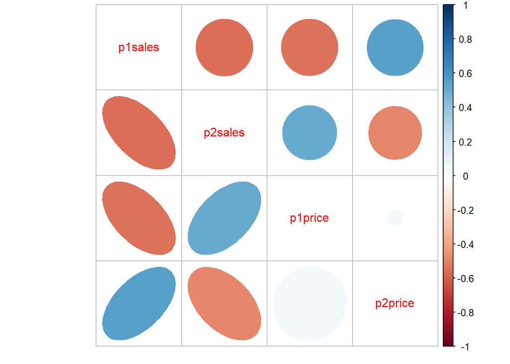

```r
library(corrplot)
library(gplots)
ques.7 <- store.df[,c('p1sales','p2sales','p1price','p2price')]
corrplot.mixed(cor(ques.7), lower = "ellipse", upper = "circle")
```

### Exercise 8 (10 Points)

- Use boxplot() to create a boxplot to compare the distributions of product 1’s weekly sales in year 1 vs. year 2

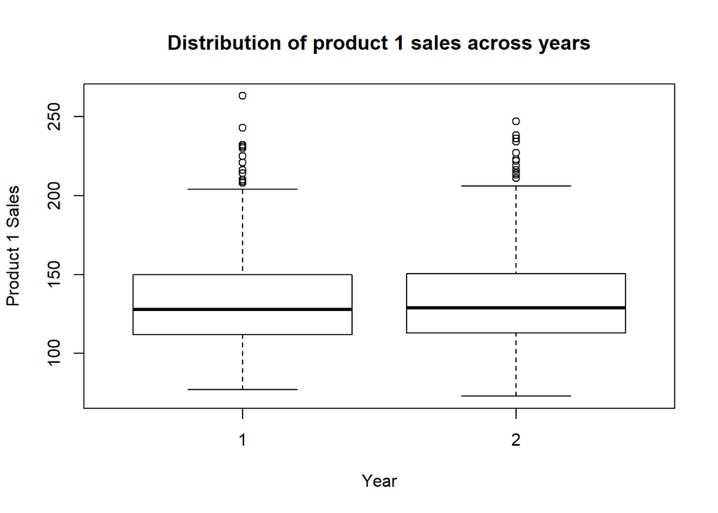

```r
boxplot(p1sales ~ Year,data = store.df, main = 'Distribution of product 1 sales across years', xlab = 'Year',ylab = 'Product 1 Sales')
```

### Exercise 9 (10 Points)

- Use bwplot() to create a multi-group boxplot to compare the distributions of product 1’s weekly sales in year 1 vs. year 2 by country
- Each boxplot in the resulting multi-group boxplot compares the annual sales districutions within a particular country

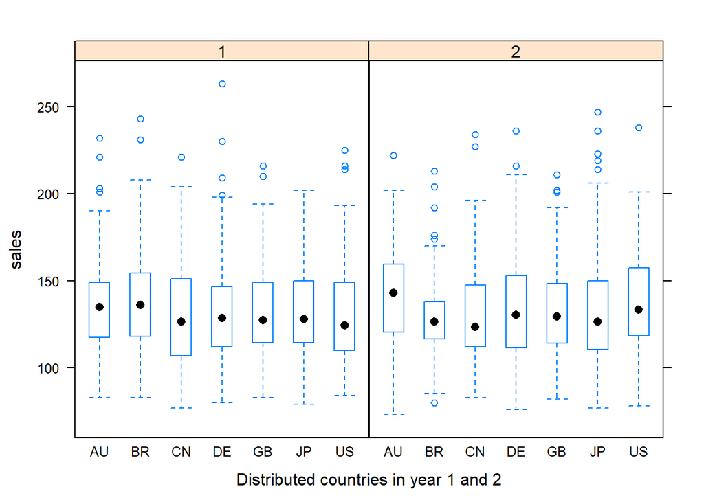

```r
store.df.duplicate <- store.df
store.df.duplicate$Year <- as.factor(store.df.duplicate$Year)
bwplot(p1sales ~ country | Year, data=store.df.duplicate,
       xlab="Distributed countries in year 1 and 2",ylab="sales",color="Red")
```

### Exercise 10 (10 Points)

- Use histogram() to create a two-way proportion bar chart with two sub charts to show the percentage of product 1 promotion within each year
- Specify the corresponding year number (1 vs. 2) in each sub chart
- Specify the binary status (0 vs. 1) of product 1 promotion for each bar

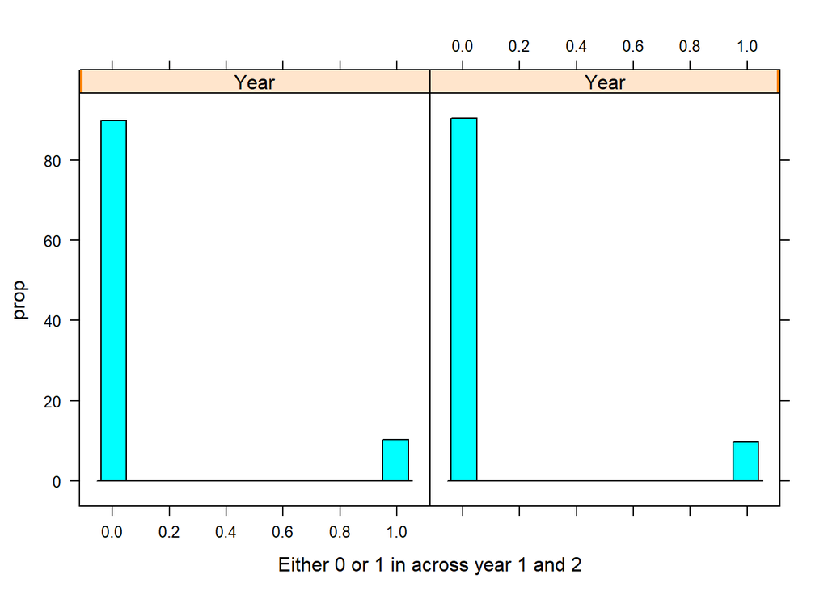

```r
histogram(~p1prom | Year, data=store.df, ylab = "prop",xlab = "Either 0 or 1 in across year 1 and 2" )
```